# Regularyzacja

Grupa Robocza Data Science PSA

Kamil Kuźmicki

## Wstęp

Zakładamy, że poruszamy się w świecie machine learningu i mamy postawiony pewien problem do rozwiązania, np. klasyfikacja lub predykcja.

**Regularyzacja jest to wprowadzenie do danego problemu dodatkowego założenia lub ograniczenia uwzględnianego przy szukaniu optymalnych parametrów.**

Z reguły stosujemy ją w przypadku kiedy:

1. problem jest źle postawiony, czyli np. mamy więcej zmiennych objaśniających niż obserwacji
2. chcemy ograniczyć zjawisko overfitting-u.

Zastosowanie regularyzacji pozwala nam też uzyskaą pewne dodatkowe informacje na temat istotności zmiennych lub ich zależności między sobą.

## Przykłady

### Przykład 1

Rozważmy standardowy problem regresji liniowej $Y \sim X$, gdzie $n$ to liczba obserwacji a $p$ to liczba zmiennych objaśniających.

Jeśli $n\geq p$, to znamy rozwiązanie tego problemu, :
$$\widehat{\beta}=(X^{T}X)^{-1}X^{T}Y$$

Ten sam wzór otrzymamy stosując oczywiście metodę największej wiarogodności.

Jeśli $n<p$, to $(X^{T}X)^{-1}$ to nie istnieje i nie istnieje też zatem jednoznaczne rozwiązanie wskazane powyżej. Oznacza to, że musimy zmodyfikować postawiony problem, np. ograniczając zbiór potencjalnych parametrów, aby mieć szansę na znalezienie rozwiązania.

### Przykład 2

Ponownie badamy zależność $Y$ od $X$ i rozważamy trzy modele liniowe, które są kolejno coraz bardziej skomplikowane:

- pierwszy (czerwony) to prosta liniowa zależność $y$ od $x$,
- drugi (zielony) to wprowadzenie dodatkowej zmiennej objaśniającej równej $x^2$
- trzeci (niebieski) wprowadza dodatkowo $x^3, x^4, \ldots x^{10}$.

Na wykresie poniżej znajdziemy predykcję dla każdego z tych modeli.

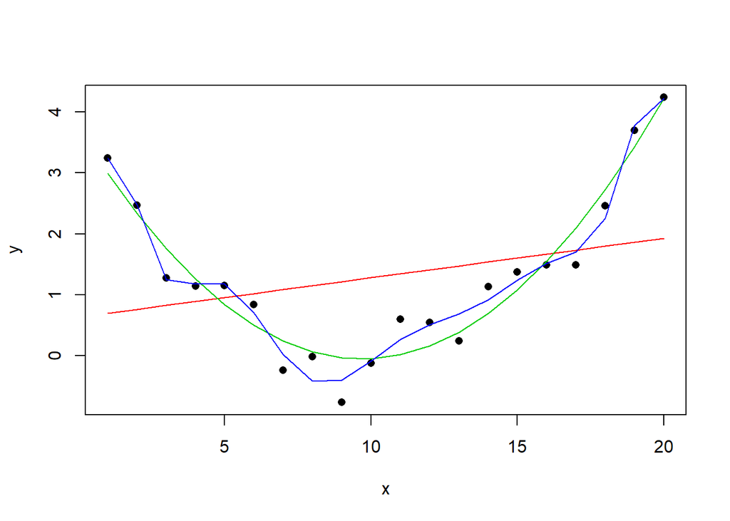

1. Pierwszy model (czerwony) faktycznie słabo łapie zależności między $y$ a $x$, co sugeruje, że ma zbyt prostą strukturę.
2. Okazuje się też, że w modelu najbardziej skomplikowanym (niebieskim) wydaje się, że może zachodzić zjawisko overfittingu.
3. Model środkowy (zielony) wydaje się najbardziej rozsądnym podejściem.

**W jaki sposób “skłonić” algorytm wyszukujący optymalne parametry, aby preferował takie właśnie rozwiązania, które nie są zbyt skomplikowane?**

## Więcej intuicji

**Brzytwa Ockhama** (nazywana także zasadą ekonomii lub zasadą ekonomii myślenia) to zasada, zgodnie z którą w wyjaśnianiu zjawisk należy dążyć do prostoty, wybierając takie wyjaśnienia, które opierają się na jak najmniejszej liczbie założeń i pojęć.

Regularyzacja pomaga zastosować tę regułę. Dodajemy dodatkowy warunek na estymowane parametry, tak, aby mieć pewność, że są one zgodne z naszymi oczekiwaniami, że dobry model jest *prosty*.

**Intuicyjnie: Im model prostszy, tym większa szansa na możliwość jego generalizacji. Im model bardziej skomplikowany, tym większa szansa, że jest on za bardzo dopasowany do danych treningowych.**

Jak mierzyć stopień skomplikowania modelu?

## Funkcja kosztu

Rozważmy próbkę $N$ obserwacji, z których każda ma $p$ zmiennych objaśniających i jedną zmienną objaśnianą. Niech $y_{i}$ będzie zmienna objaśnianą i $x_{i} = (x_{i,1},x_{i,2},\ldots ,x_{i,p})^{T}$ będą zmiennymi objaśniającymi.

Problem poszukiwania optymalnych parametrów $\widehat{\beta}$ można sprowadzić do poszukiwania $\beta _{0},\beta$ minimalizujących
$$\sum _{i=1}^{N}(y_{i}-\beta _{0}-x_{i}^{T}\beta )^{2}.$$
Jest to tzw. metoda najmniejszych kwadratów.

Powyższe wyrażenie możemy zapisać jako funkcję kosztu $J(x, y, \beta _{0},\beta)$ związaną z tymi parametrami oraz z danymi $x$ i $y$:

$$J(x, y, \beta _{0},\beta) = \sum _{i=1}^{N}(y_{i}-\beta _{0}-x_{i}^{T}\beta )^{2}.$$
W tym kontekście, problem regresji liniowej to poszukiwanie optymalnych parametrów $\beta _{0},\beta$ minimalizujących wartości funkcji kosztu. W standardowym modelu nie wprowadzamy dodatkowych ograniczeń na $\beta _{0},\beta$.

## Regularyzacja

Regularyzację można wprowadzić za pomocą wprowadzenia dodatkowych warunków przy poszukiwaniu tych parametrów na dwa sposoby:

1. Minimalizujemy koszt $J(x, y, \beta _{0},\beta)$, dla pewnego ograniczonego podzbioru $\beta _{0},\beta$ (zamiast dla dowolnych)
2. Minimalizujemy koszt $J(x, y, \beta _{0},\beta) + f(\beta _{0},\beta)$, gdzie $f(\beta _{0},\beta)$ oznacza dodatkowy koszt dla parametrów $\beta _{0},\beta$.

Przykładem funkcji może być $f(\beta _{0},\beta) = \lambda \sum_{i=0}^{p}|{\beta _{i}}|$ i jest to wtedy tzw. regularyzacja Lasso.

## Metody

W poniższych analizach wykorzystam zbiór danych BostonHousing (https://www.kaggle.com/c/boston-housing). Zbiór zawiera informację o cenach domów wraz z zestawem parametrów opisujących daną nieruchomość. Zadaniem jest estymacja ceny domu na podstawie dostępnych informacji.

#### R

W R podstawowe techniki regularyzacji w ramach modelu liniowego można zastosować używając funkcji *glmnet* z pakietu *glmnet*.

Składnia:

**glmnet***(x, y, family = “gaussian”, lambda = NULL, alpha = 1, …)*

- Szczegóły: https://www.rdocumentation.org/packages/glmnet/versions/3.0-2/topics/glmnet
- W przypadku nie wybrania $\lambda$, funkcja *glmnet* zwróci wyniki dla zestawu $\lambda$.

#### Python

W Python można wykorzystać klasę *Elastic Net* z pakietu *sklearn.linear_model*.

Składnia:

*class* sklearn.linear_model.**ElasticNet***(alpha=1.0, l1_ratio=0.5, …)*

- Szczegóły: https://scikit-learn.org/stable/modules/generated/sklearn.linear_model.ElasticNet.html
- Porównanie do R: zmienna *alpha* odpowiada *lambda* , a *l1_ratio* odpowiada *alpha*.

### Lasso

W porównaniu do metody najmniejszych kwadratów wprowadzamy ograniczenie na parametry.
$$\sum_{i=0}^{p}|{\beta _{i}}| < \alpha.$$
Dla pewnego $\lambda > 0$, taki problem jest równoważny do poszukiwania $\beta _{0},\beta$ minimalizujących
$$J(x, y, \beta _{0},\beta) + \lambda \sum_{i=0}^{p}|{\beta _{i}}|.$$

*(Przypomnienie: $J(x, y, \beta _{0},\beta)$ to podstawowa funkcja kary dla modelu liniowego.)*

Kod R:

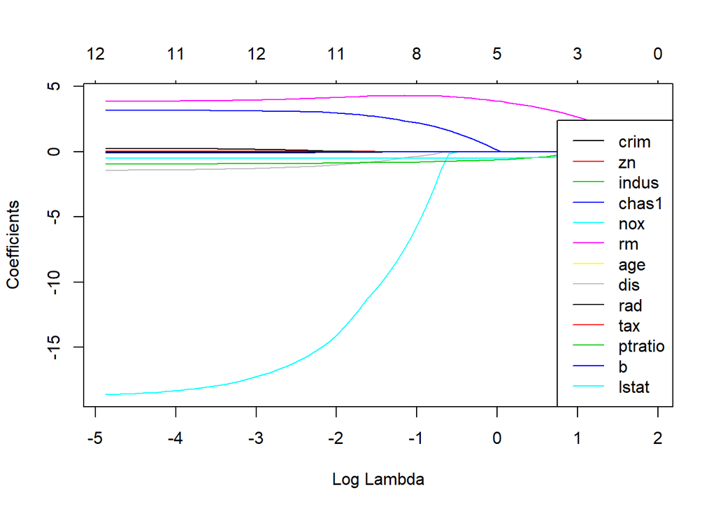

```r
ALPHA = 1

fit <- glmnet(x.train, y.train, family = "gaussian", alpha = ALPHA)

plot(fit, xvar = "lambda", col = 1:dim(coef(fit))[1])

lbs_fun(fit)
```

- Im $\lambda$ jest większe, tym bardziej znacząca jest “kara” związana z $\sum_{i=0}^{p}|{\beta _{i}}|$, co prowadzi do coraz mniejszych wartości parametrów.
- Algorytm preferuje takie $\beta$, że niektóre z nich są równe 0
- W przypadku jeśli niektóre zmienne objaśniające są bardzo podobne lub mocno skorelowane nie ma jednoznaczoności (koszt dla $(0,\beta_i)$ jest taki sam co dla $(\frac{\beta_i}{2}, \frac{\beta_i}{2})$)

### Ridge

W porównaniu do metody najmniejszych kwadratów wprowadźmy ograniczenie na parametry.
$$\sum_{i=0}^{p}|{\beta _{i}}|^2 < \alpha.$$
Dla pewnego $> 0 $, taki problem jest równoważny do poszukiwania $\beta _{0},\beta$ minimalizujących
$$J(x, y, \beta _{0},\beta) + \lambda \sum_{i=0}^{p}|{\beta _{i}}|^2.$$

Kod R:

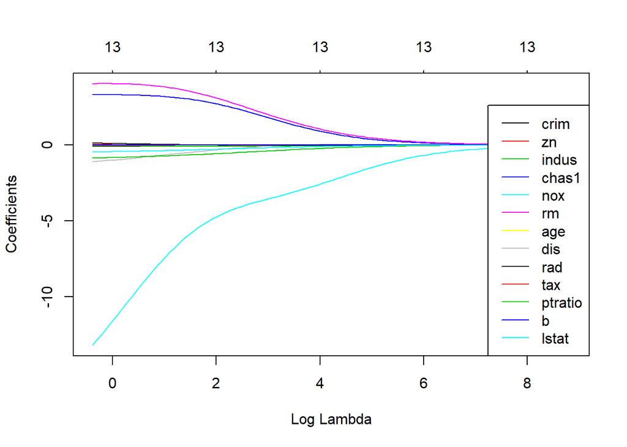

```r
ALPHA = 0

fit <- glmnet(x = x.train, y = y.train, family = "gaussian", alpha = ALPHA)

plot(fit, xvar = "lambda", col = 1:dim(coef(fit))[1])

lbs_fun(fit) # funkcja poprawiająca wykres
```

- Im $\lambda$ jest większe, tym bardziej znacząca jest “kara” związana z $\sum_{i=0}^{p}|{\beta _{i}}|^2$, co prowadzi do coraz mniejszych wartości parametrów. Odbywa się to jednak “wolniej” niż dla Lasso
- W przeciwieństwie do Lasso, algorytm zwykle zwraca $\beta$ różne od $0$
- W przypadku jeśli niektóre zmienne objaśniające są bardzo podobne lub mocno skorelowane, algorytm przeprowadza “grupowanie zmiennych” i wybiera taki zestaw parametrów, gdzie podobne lub mocno skorelowane zmienne objaśniające mają ten sam parametr

### Elastic net

W porównaniu do metody najmniejszych kwadratów wprowadzamy ograniczenie na parametry.
$$\sum_{i=0}^{p}(\theta|{\beta _{i}}|+(1-\theta)|{\beta _{i}}|^2) < \alpha.$$
Dla pewnego $\lambda > 0$, taki problem jest równoważny do poszukiwania $\beta _{0},\beta$ minimalizujących
$$J(x, y, \beta _{0},\beta) + \lambda \sum_{i=0}^{p}(\theta|{\beta _{i}}|+(1-\theta)|{\beta _{i}}|^2).$$
Kod R:

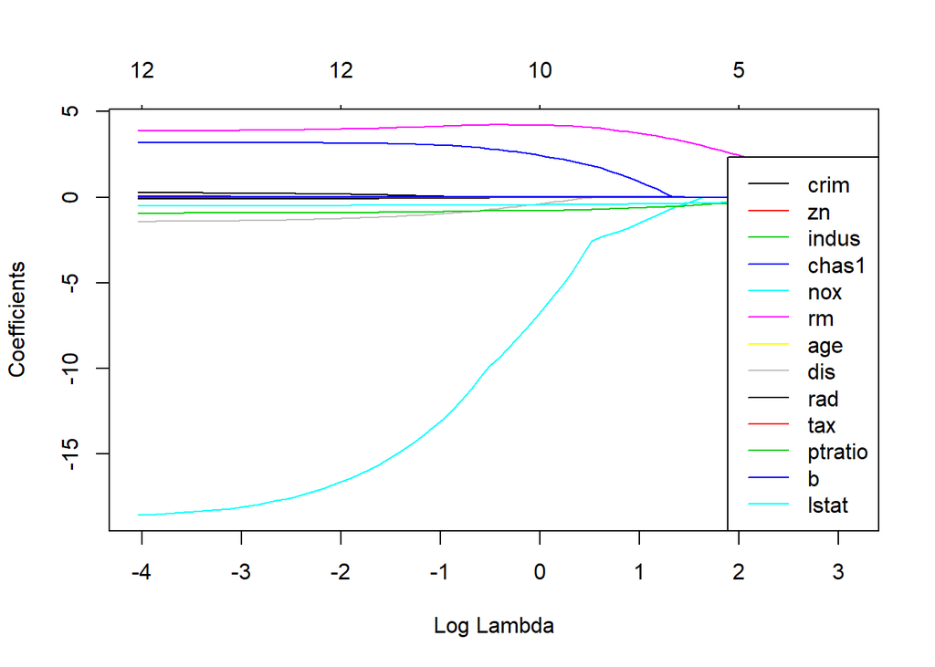

```r
ALPHA = 0.3 # przykładowo, może to być dowolna liczba z przedziału [0, 1]

fit <- glmnet(x = x.train, y = y.train, family = "gaussian", alpha = ALPHA)

plot(fit, xvar = "lambda", col = 1:dim(coef(fit))[1])

lbs_fun(fit) # funkcja poprawiająca wykres
```

- Jest to rozwiązanie pomiędzy Lasso i Ridge regression
- Pozwala na grupowanie zmiennych, ale również na “zerowanie” parametrów przy niektórych zmiennych

## Uwagi końcowe

- Regularyzacja jest często dobrym pomysłem w sytuacji, gdy mamy dużo zmiennych objaśniających, z których każda stopniowo dostarcza dodatkowych informacji lub kiedy potrzebujemy ocenić jakie zmienne są potencjalnie istotne a jakie nie.
- Powyższe metody można łatwo ugólnić na bardziej skomplikowane modele takie jak regresja logistyczna, GLM.
- Hiperparametry $\lambda, \theta$ można dobrać korzystając z techniki cross-walidacji
- Przed uruchomieniem powyższych algorytmów zwykle normalizuje się zmienne objaśniające (czyli zapewnia, że wszystkie mają taki sam zakres i średnią). Pozwoli to uniknąć nierównowagi między parametrami oraz poprawia zbieżność algorytmów optymalizujących. W praktyce wystarczy upewnić się, że jest zaznaczona ta opcja przy wywoływaniu funkcji.
- *Ciekawostka*: Metody Lasso, Ridge, czy Elastic Net to tak naprawdę założenie, że parametry są również zmiennymi losowymi z pewnego rozkładu a priori (podejście Bayesowskie).
- *Ciekawostka*: Metody szukania optymalnego zestawu zmienny oparte o AIC i BIC są również metodami opartymi o regularyzację. Wprowadza się w nich pewne ograniczenie na liczbę parametrów, ale wciąż jest to funkcja postaci $f(\beta _{0},\beta)$.

## Literatura

Regression Shrinkage and Selection via the Lasso, Robert Tibshirani, Journal of the Royal Statistical Society. Series B (Methodological), Vol. 58, No. 1 (1996), pp. 267-288

https://www.coursera.org/learn/machine-learning/home/welcome

https://en.wikipedia.org/wiki/Regularization_(mathematics)

https://en.wikipedia.org/wiki/Lasso_(statistics)

https://en.wikipedia.org/wiki/Linear_regression

http://www.science.smith.edu/~jcrouser/SDS293/labs/lab10-r.html

https://cran.r-project.org/web/packages/glmnet/glmnet.pdf

https://web.stanford.edu/~hastie/StatLearnSparsity_files/SLS.pdf

https://www.rstatisticsblog.com/data-science-in-action/lasso-regression/

https://scikit-learn.org/stable/modules/generated/sklearn.linear_model.ElasticNet.html